# Cox proportional hazards regression - Squid Game style - Episode 5 - Glass Tile

## Installing required packages

```r
# to install the other packages, run the codes below
 #install.packages("survival")
 #install.packages("survminer")
 #install.packages("gtsummary")
```

## Loading packages

```r
library("survival")
library("survminer")
library("gtsummary")
```

## Load dataset

```r
data <- read.csv("glass_tile_dataset.csv")
head(data)
```

|  | time | status | age | sex | stability | glass_assessment_ability | calories | weight_loss |
| --- | --- | --- | --- | --- | --- | --- | --- | --- |
| 1 | 883 | 1 | 60 | Male | 100 | 90 | NA | 0 |
| 2 | 218 | 1 | 53 | Male | 70 | 80 | 825 | 16 |
| 3 | 144 | 1 | 67 | Male | 80 | 90 | NA | 15 |
| 4 | 61 | 1 | 56 | Female | 60 | 60 | 238 | 10 |
| 5 | 12 | 1 | 74 | Male | 70 | 50 | 305 | 20 |
| 6 | 26 | 1 | 73 | Male | 60 | 70 | 388 | 20 |

##### Explanation of dataset

- `time` survival time in minutes since the start of the game
- `status` 1 is dead, 0 is censored
- `age` age of player
- `sex` sex of player
- `stability` balance skills, good is 100, bad is 0
- `glass_assessment_ability` ability to evaluate glass material, good is 100, bad is 0
- `calories` amount of calories consumed during last meal
- `weight_loss` amount of weight loss since joining the squid game in pounds

## Fitting a Cox proportional hazards model

Running multivariate Cox regresion of time to death on the time-constant covariates.

```r
surv_object <- Surv(time = data$time, event = data$status)

model <- coxph(surv_object ~ age + sex + stability + glass_assessment_ability + calories + weight_loss,
                   data = data)

summary(model)
```

```
## Call:
## coxph(formula = surv_object ~ age + sex + stability + glass_assessment_ability +
##     calories + weight_loss, data = data)
##
##   n= 169, number of events= 122
##    (59 observations deleted due to missingness)
##
##                                coef  exp(coef)   se(coef)      z Pr(>|z|)
## age                       0.0090807  1.0091220  0.0117503  0.773   0.4396
## sexMale                   0.4859823  1.6257713  0.1995728  2.435   0.0149 *
## stability                -0.0023393  0.9976635  0.0079466 -0.294   0.7685
## glass_assessment_ability -0.0193962  0.9807907  0.0077533 -2.502   0.0124 *
## calories                  0.0000126  1.0000126  0.0002460  0.051   0.9592
## weight_loss              -0.0080307  0.9920014  0.0073014 -1.100   0.2714
## ---
## Signif. codes:  0 '***' 0.001 '**' 0.01 '*' 0.05 '.' 0.1 ' ' 1
##
##                          exp(coef) exp(-coef) lower .95 upper .95
## age                         1.0091     0.9910    0.9861    1.0326
## sexMale                     1.6258     0.6151    1.0995    2.4040
## stability                   0.9977     1.0023    0.9822    1.0133
## glass_assessment_ability    0.9808     1.0196    0.9660    0.9958
## calories                    1.0000     1.0000    0.9995    1.0005
## weight_loss                 0.9920     1.0081    0.9779    1.0063
##
## Concordance= 0.634  (se = 0.029 )
## Likelihood ratio test= 17.53  on 6 df,   p=0.008
## Wald test            = 16.83  on 6 df,   p=0.01
## Score (logrank) test = 17.22  on 6 df,   p=0.008
```

#### Intrepretation of results

- The overall p-value for all three tests are significant.
  - `Likelihood ratio test` p=0.008
  - `Wald test` p=0.01
  - `Logrank test` p=0.008

This indicates that the model is significant. These tests assess the null hypothesis that all of the betas are zero and the null hypothesis is rejected.

In this multivariate analysis, the covariates `sex` and `glass_assessment_ability` remain significant (p < 0.05). But all other covariates were not significant.

The p-value for `sex` is 0.01, with a hazard ratio (exp(coef)) of 1.6 suggesting a relationship between players’ sex and increased risk of death.

The p-value for `glass_assessment_ability` is 0.01 with a hazard ratio (exp(coef)) of 0.98 indicating a relationship between players glass assessment ability and decreased risk of death. This means that players who have higher skills at identifying tempered glass have a lower risk of dying and winning the game.

## Displaying clean tables

Use `tbl_regression` from the `gtsummary` package to get a tidy version of the output.

```r
tbl_regression(model, exponentiate = TRUE) %>%
  as_gt() %>%
  gt::tab_source_note(gt::md("*Covariates affecting players ability to win the Glass Tile game *"))
```

| **Characteristic** | **HR**<sup>1</sup> | **95% CI**<sup>1</sup> | **p-value** |
| --- | --- | --- | --- |
| age | 1.01 | 0.99, 1.03 | 0.4 |
| sex |  |  |  |
| Female | — | — |  |
| Male | 1.63 | 1.10, 2.40 | 0.015 |
| stability | 1.00 | 0.98, 1.01 | 0.8 |
| glass_assessment_ability | 0.98 | 0.97, 1.00 | 0.012 |
| calories | 1.00 | 1.00, 1.00 | >0.9 |
| weight_loss | 0.99 | 0.98, 1.01 | 0.3 |

*Covariates affecting players ability to win the Glass Tile game *  
<sup>*1*</sup> HR = Hazard Ratio, CI = Confidence Interval

## Plotting results

Use `ggforest` to generate a forest plot.

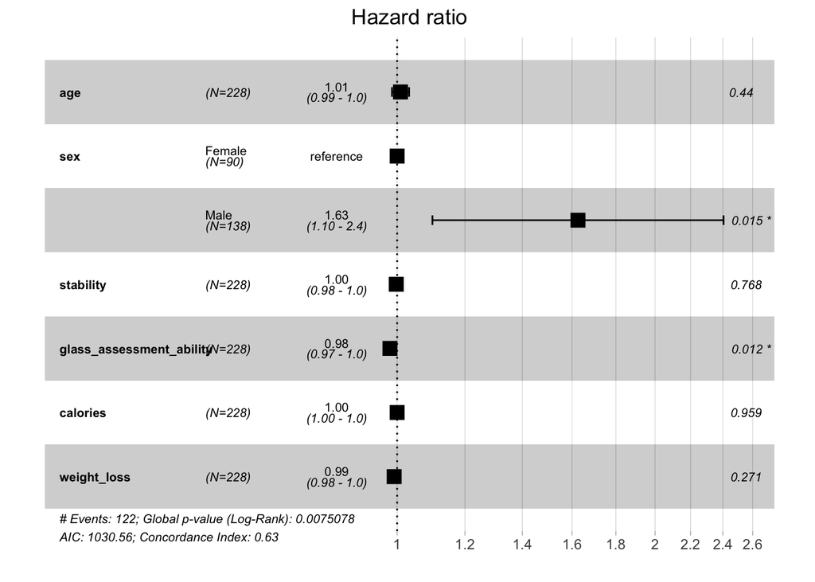

```r
ggforest(model, data = data)
```